# R Notebook

```r
library(tidyverse)
library(janitor)
library(infer)
library(here)
here::here()
```

```
[1] "C:/Users/colin/Documents/CodeClan/codeclan_homework_ColinS/week_06/day_3"
```

# 1. MVP

## Task 1.

Load the data again, clean_names(), and re-familiarise yourself with it

```r
ames <- read_csv(here("data/ames.csv")) %>% clean_names()
```

```r
head(ames)
```

| order | pid | ms_sub_class | ms_zoning | lot_frontage | lot_area | street | alley | lot_shape | land_contour | utilities | lot_config | land_slope | neighborhood | condition_1 | condition_2 | bldg_type | house_style | overall_qual | overall_cond | year_built | year_remod_add | roof_style | roof_matl | exterior_1st | exterior_2nd | mas_vnr_type | mas_vnr_area | exter_qual | exter_cond | … |
| --- | --- | --- | --- | --- | --- | --- | --- | --- | --- | --- | --- | --- | --- | --- | --- | --- | --- | --- | --- | --- | --- | --- | --- | --- | --- | --- | --- | --- | --- | --- |
| 1 | 526301100 | 20 | RL | 141 | 31770 | Pave | NA | IR1 | Lvl | AllPub | Corner | Gtl | NAmes | Norm | Norm | 1Fam | 1Story | 6 | 5 | 1960 | 1960 | Hip | CompShg | BrkFace | Plywood | Stone | 112 | TA | TA | … |
| 2 | 526350040 | 20 | RH | 80 | 11622 | Pave | NA | Reg | Lvl | AllPub | Inside | Gtl | NAmes | Feedr | Norm | 1Fam | 1Story | 5 | 6 | 1961 | 1961 | Gable | CompShg | VinylSd | VinylSd | None | 0 | TA | TA | … |
| 3 | 526351010 | 20 | RL | 81 | 14267 | Pave | NA | IR1 | Lvl | AllPub | Corner | Gtl | NAmes | Norm | Norm | 1Fam | 1Story | 6 | 6 | 1958 | 1958 | Hip | CompShg | Wd Sdng | Wd Sdng | BrkFace | 108 | TA | TA | … |
| 4 | 526353030 | 20 | RL | 93 | 11160 | Pave | NA | Reg | Lvl | AllPub | Corner | Gtl | NAmes | Norm | Norm | 1Fam | 1Story | 7 | 5 | 1968 | 1968 | Hip | CompShg | BrkFace | BrkFace | None | 0 | Gd | TA | … |
| 5 | 527105010 | 60 | RL | 74 | 13830 | Pave | NA | IR1 | Lvl | AllPub | Inside | Gtl | Gilbert | Norm | Norm | 1Fam | 2Story | 5 | 5 | 1997 | 1998 | Gable | CompShg | VinylSd | VinylSd | None | 0 | TA | TA | … |
| 6 | 527105030 | 60 | RL | 78 | 9978 | Pave | NA | IR1 | Lvl | AllPub | Inside | Gtl | Gilbert | Norm | Norm | 1Fam | 2Story | 6 | 6 | 1998 | 1998 | Gable | CompShg | VinylSd | VinylSd | BrkFace | 20 | TA | TA | … |

[output not shown]

```r
glimpse(ames)
```

```
Rows: 2,930
Columns: 82
$ order           <dbl> 1, 2, 3, 4, 5, 6, 7, 8, 9, 10, 11, 12, 13, 14, 15, 16, 17, 18, 19, 2~
$ pid             <dbl> 526301100, 526350040, 526351010, 526353030, 527105010, 527105030, 52~
$ ms_sub_class    <dbl> 20, 20, 20, 20, 60, 60, 120, 120, 120, 60, 60, 20, 60, 20, 120, 60, ~
$ ms_zoning       <chr> "RL", "RH", "RL", "RL", "RL", "RL", "RL", "RL", "RL", "RL", "RL", "R~
$ lot_frontage    <dbl> 141, 80, 81, 93, 74, 78, 41, 43, 39, 60, 75, NA, 63, 85, NA, 47, 152~
$ lot_area        <dbl> 31770, 11622, 14267, 11160, 13830, 9978, 4920, 5005, 5389, 7500, 100~
$ street          <chr> "Pave", "Pave", "Pave", "Pave", "Pave", "Pave", "Pave", "Pave", "Pav~
$ alley           <chr> NA, NA, NA, NA, NA, NA, NA, NA, NA, NA, NA, NA, NA, NA, NA, NA, NA, ~
$ lot_shape       <chr> "IR1", "Reg", "IR1", "Reg", "IR1", "IR1", "Reg", "IR1", "IR1", "Reg"~
$ land_contour    <chr> "Lvl", "Lvl", "Lvl", "Lvl", "Lvl", "Lvl", "Lvl", "HLS", "Lvl", "Lvl"~
$ utilities       <chr> "AllPub", "AllPub", "AllPub", "AllPub", "AllPub", "AllPub", "AllPub"~
$ lot_config      <chr> "Corner", "Inside", "Corner", "Corner", "Inside", "Inside", "Inside"~
$ land_slope      <chr> "Gtl", "Gtl", "Gtl", "Gtl", "Gtl", "Gtl", "Gtl", "Gtl", "Gtl", "Gtl"~
```

[output cut: 69 more lines]

## Task 2.

Investigate the distribution of lot_area. Is the distribution roughly normal? If not, what problems do you find?

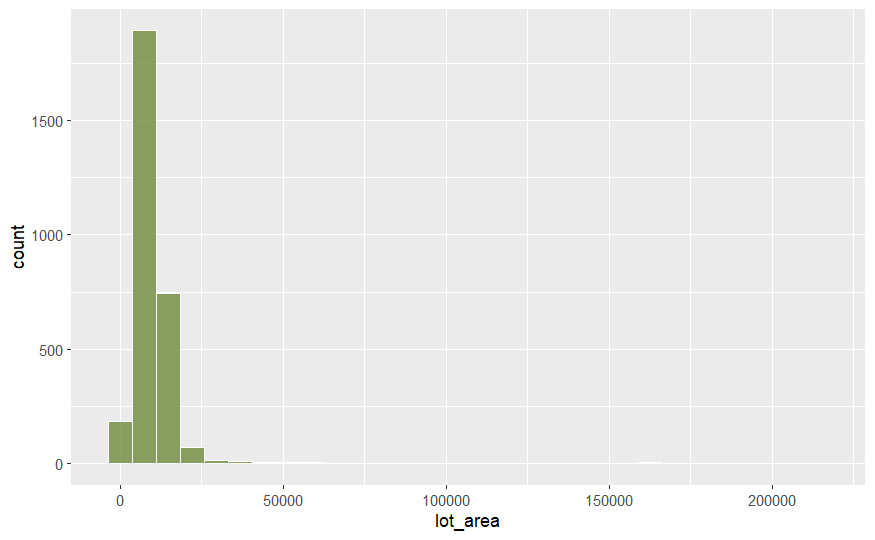

```r
ames %>%
  ggplot() +
  aes(x = lot_area) +
  geom_histogram(colour = "white", fill = "darkolivegreen4", alpha = 0.8)
```

The lot_area data is right skewed as a result of a very small proportion of houses having large lot areas.

## Task 3.

Compute and visualise a bootstrap sampling distribution for the mean(lot_area) of the sold houses.

```r
bootstrap_lot_200 <- ames %>%
    rep_sample_n(size =200, replace = TRUE, reps = 5000) %>%
    summarise(mean_lot_area = mean(lot_area))
```

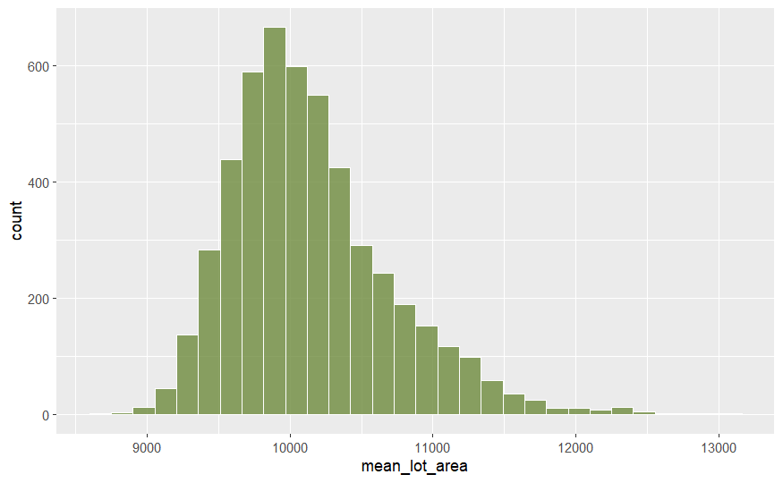

```r
bootstrap_lot_200 %>%
ggplot() +
  aes(x = mean_lot_area) +
  geom_histogram(colour = "white", fill = "darkolivegreen4", alpha = 0.8)
```

## Task 4.

Use your bootstrap distribution to calculate a 95% CI for mean(lot_area), and visualise it on the distribution

[output not shown]

[output cut: 990 more lines]

Our 95% confidence intervals are; lower; 9285.446 upper; 11438.1

```r
infer_resample <- ames %>%
  # which variable are we interested in:
  specify(response = lot_area) %>%
  # the replicates to resample:
  generate(reps = 5000, type = "bootstrap") %>%
  # statistic we're interested in for each resample:
  calculate(stat = "mean")

infer_resample
```

```
Response: lot_area (numeric)
```

| replicate | stat |
| --- | --- |
| 1 | 10019.595 |
| 2 | 10065.654 |
| 3 | 9992.043 |
| 4 | 9982.596 |
| 5 | 10085.244 |
| 6 | 10329.710 |
| 7 | 10209.700 |
| 8 | 10039.595 |
| 9 | 10174.300 |
| 10 | 9720.945 |

[output cut: 990 more lines]

```r
infer_ci_95 <- infer_resample %>%
  get_confidence_interval(level = 0.95, type = "percentile")
infer_ci_95
```

| lower_ci | upper_ci |
| --- | --- |
| 9884.832 | 10450.03 |

**I’d already calculated CIs above in line 62: do I really need to do more reps** **as shown in lines 70 - 80 (and get different results!) in order to overlay the** **shading? Without doing this resampling I always got the error:** `Don't know how to automatically pick scale for object of type function.` `Defaulting to continuous.`

**Looking at `?visualise` shows:**

data  
A distribution. For simulation-based inference, a data frame containing a distribution of calculate()d statistics or fit()ted coefficient estimates

**so does this mean that `visualise` only works with CIs that have been `calculate`d** **using the `infer` package?**

**I understand the CI principles, I just don’t get why I need to resample in lines** **70 - 80…**

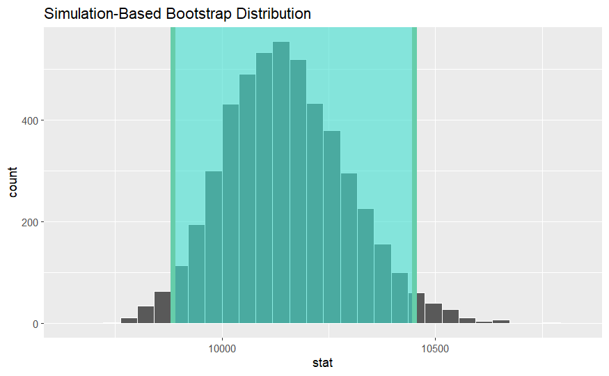

```r
infer_resample %>%
  visualise(bins = 30) +
  shade_confidence_interval(endpoints = infer_ci_95)
```

## Task 5.

You would like to know the mean(lot_area) of the sold houses with higher confidence. Calculate the 99% CI for this variable (you can re-use your bootstrap distribution from above). Is it narrower or broader than the 95% CI? Does that make sense?

The 99% CI shading should be broader than 95% CI.

```r
infer_ci_99 <- infer_resample %>%
  get_confidence_interval(level = 0.99, type = "percentile")
infer_ci_99
```

| lower_ci | upper_ci |
| --- | --- |
| 9815.213 | 10558.75 |

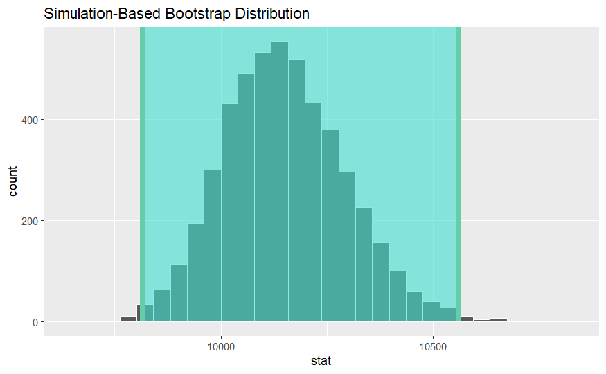

```r
infer_resample %>%
  visualise(bins = 30) +
  shade_confidence_interval(endpoints = infer_ci_99)
```

## Task 6.

Calculate the point estimate of the mean(lot_area)

```r
mean_infer <- infer_resample %>%
  summarise(mean = mean(stat))
mean_infer
```

| mean |
| --- |
| 10149.63 |

The Point Estimate of the mean is 10149.63.

# 2 Extension

## Task 1.

Calculate a point estimate and 95% CI for the proportion of houses in the data built before 1920. Does the number of reps you use matter? [Investigate reps from 200 up to 50000, memory of your laptop permitting].